# Analyse zur Vorhersage chronischer Nierenerkrankungen

Konstantin Krönauer

23-June-2024

# Einleitung

Chronische Nierenerkrankung (CKD) ist ein bedeutendes Gesundheitsproblem weltweit. Diese Studie zielt darauf ab, ein Modell zu entwickeln, um das Risiko einer CKD anhand klinischer Merkmale vorherzusagen.

## Forschungsfrage

Kann ein Modell entwickelt werden, um das Risiko einer chronischen Nierenerkrankung anhand der vorgegebenen Merkmale vorherzusagen?

## Datenbeschreibung

Das verwendete Datenset enthält klinische Merkmale und Laborergebnisse von Patienten. Das Hauptziel ist die Klassifizierung der Patienten in zwei Kategorien: CKD und nicht CKD.

### Daten-Vorverarbeitung

Vor der Modellerstellung wurden mehrere Vorverarbeitungsschritte durchgeführt:

- Behandlung von fehlenden Werten durch Entfernen der entsprechenden Datensätze.
- Konvertierung aller Merkmale in Faktoren für die Modellierung mit einem Entscheidungsbaum.
- Entfernen leerer und seltener Klassen, um die Robustheit des Modells zu gewährleisten.

```r
  if (!require(rpart.plot)) install.packages("rpart.plot", dependencies=TRUE)
  if (!require(caret)) install.packages("caret", dependencies=TRUE)
  if (!require(tidyverse)) install.packages("tidyverse", dependencies=TRUE)

  library(caret)
  library(ggplot2)
  library(stringr)
  library(tidyverse)
  library(rpart)
  library(rpart.plot)
  library(e1071)


# Datensatz einlesen
data <- read.csv("ckd-dataset.csv")

# Die ersten Reihen des Datensatzes anzeigen
head(data)

# Zeilen mit leeren werten entfernen
data <- na.omit(data)

# Alle spalten Faktorisieren
data <- data %>% mutate(across(everything(), as.factor))

# Leere oder seltene Klassen entfernen
data <- data[!data$class %in% c("", "discrete"), ]

# Die Struktur des Datensatzes verifizieren
str(data)
```

[output not shown]

## Modellbildung

Ein Entscheidungsbaummodell wurde verwendet, um die CKD-Status vorherzusagen. Die Daten wurden in Trainings- (80%) und Testsets (20%) aufgeteilt.

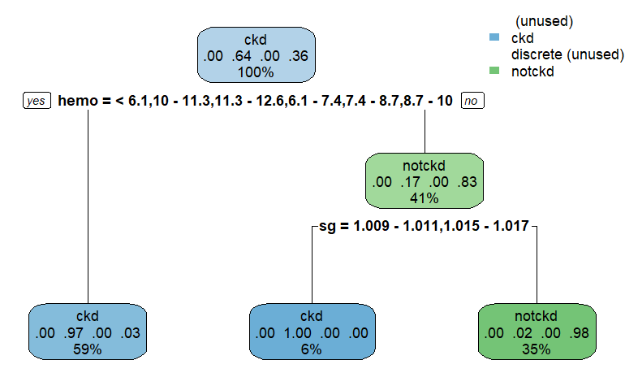

```r
# Modellbildung mit Entscheidungsbaum

set.seed(123)
trainIndex <- createDataPartition(data$class, p = .8, list = FALSE, times = 1)
dataTrain <- data[trainIndex, ]
dataTest <- data[-trainIndex, ]


model <- rpart(class ~ . - affected - stage, data = dataTrain, method = "class")

# Visualisierung des Entscheidungsbaums
rpart.plot(model)
```

## Modell Evaluation

Die Leistung des Modells wurde mit einem Testdatensatz ausgewertet.

```r
# Vorhersage machen
predictions <- predict(model, dataTest, type = "class")
predictions <- droplevels(predictions)
dataTest$class <- factor(dataTest$class, levels = c("ckd", "notckd"))

# Konfusionsmatrix
confMatrix <- confusionMatrix(predictions, dataTest$class)
print(confMatrix)
```

```
Confusion Matrix and Statistics

          Reference
Prediction ckd notckd
    ckd     25      1
    notckd   0     13

               Accuracy : 0.9744
                 95% CI : (0.8652, 0.9994)
    No Information Rate : 0.641
    P-Value [Acc > NIR] : 6.712e-07

                  Kappa : 0.9434

 Mcnemar's Test P-Value : 1

            Sensitivity : 1.0000
            Specificity : 0.9286
         Pos Pred Value : 0.9615
         Neg Pred Value : 1.0000
             Prevalence : 0.6410
         Detection Rate : 0.6410
   Detection Prevalence : 0.6667
      Balanced Accuracy : 0.9643

       'Positive' Class : ckd
```

```r
# Berechnung der Genauigkeit
accuracy <- sum(predictions == dataTest$class) / nrow(dataTest)
print(paste("Accuracy:", round(accuracy, 4)))
```

```
[1] "Accuracy: 0.9744"
```

## Variable Importance

Die folgenden Merkmale tragen am meisten zur Vorhersage der CKD bei:

```r
vvar_importance <- varImp(model)
print(var_importance)
```

|  | Overall |
| --- | --- |
| al | 10.87571 |
| grf | 46.50296 |
| hemo | 50.06732 |
| htn | 10.87571 |
| pcv | 52.59984 |
| rbcc | 33.95044 |
| sg | 47.71066 |
| bp..Diastolic. | 0.00000 |
| bp.limit | 0.00000 |
| rbc | 0.00000 |

[output cut: 16 more lines]

[figure not shown]

```r
plot(var_importance)
```

```r
# Variable importance directly from rpart model
importance <- model$variable.importance
print(importance)
```

```
     hemo       pcv        sg       grf      rbcc        al        dm       htn        su       bgr
50.067320 37.929788 33.816750 31.102426 27.309448 26.390822  9.821429  8.184524  6.547619  4.910714
```

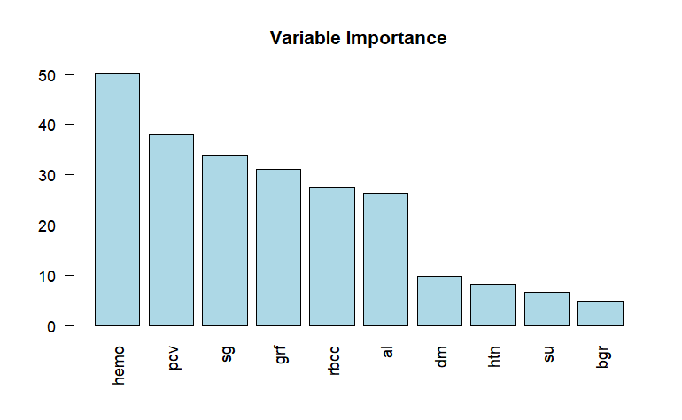

```r
barplot(importance, main = "Variable Importance", col = "lightblue", las = 2)
```

```r
var_importance_df <- data.frame(
  Feature = rownames(var_importance$importance),
  Importance = var_importance$importance[, 1]
)
```

## Schlussfolgerungen

Die hohe Genauigkeit des Modells deutet darauf hin, dass es ein wertvolles Werkzeug für die frühzeitige Erkennung von CKD sein kann. Zukünftige Arbeiten könnten die Validierung des Modells an größeren und vielfältigeren Datensätzen sowie die Exploration anderer Machine-Learning-Algorithmen zur Verbesserung der Leistung umfassen.